# Predict manner from barbell lifts activity recorded by accelerometers

David Zhiqiang MA Adam

Friday, April 24, 2015

### Overview

Using wearable devices such as Jawbone Up, Nike FuelBand, and Fitbit now very easily give us an posibility to collect a large amount of data about personal activity and which then can be analyzed for business or healthcare research usage.

In this paper, the author will intorduce one of the most accuracy Machine Learning technique named “Random Forest” to demo a medium sized but overall process of analyzing of realistic data acquired from several volunteers. During data collected, accelerometers were attached on the belt, forearm, arm, and dumbell of 6 participants who were asked to perform barbell lifts correctly and incorrectly in 5 different ways.

With the [real data](https://d396qusza40orc.cloudfront.net/predmachlearn/pml-training.csv) and [test data-20 cases](https://d396qusza40orc.cloudfront.net/predmachlearn/pml-testing.csv), the factor column classe contians 5 manner lettered from A through E and only A represents the correct manner. More information is available from the HAR website [here](http://groupware.les.inf.puc-rio.br/har) (see the section on the Weight Lifting Exercise Dataset).

It’s also published on [RPubs](http://rpubs.com/DavidMzq/76178).

### Data Cleaning:

```r
library(caret); library(kernlab);
#Read data into variable
TrainDataOri<-read.table("pml-training.csv",header=TRUE,sep=",",na.strings="NA")
#Create sub-training and sub-test dataset
inTrain <- createDataPartition(TrainDataOri$classe,p=0.7, list=FALSE)
training <- TrainDataOri[inTrain,]
testing <- TrainDataOri[-inTrain,]
#remove columns
# 1.remove derivative volumns which with prefix max_, kurtosis_, skewness_, min_, var_, avg_, stddev_
testingNew <- testing[,!grepl("max_|min_|kurtosis_|skewness_|var_|avg_|stddev_",names(testing))]
trainingNew <- training[,!grepl("max_|min_|kurtosis_|skewness_|var_|avg_|stddev_",names(training))]
# 2.remove row number and user name
testingNew <- testingNew[ , !names(testingNew) %in% c("X","user_name")]
trainingNew <- trainingNew[ , !names(trainingNew) %in% c("X","user_name")]
# 3.remove timestamp
testingNew <- testingNew[,!grepl("timestamp",names(testingNew))]
trainingNew <- trainingNew[,!grepl("timestamp",names(trainingNew))]
# 4.remove columns which are empty in test dataset(columns with prefix amplitude), avoiding unnecessary unmatching occur.
testingNew <- testingNew[,!grepl("amplitude_",names(testingNew))]
trainingNew <- trainingNew[,!grepl("amplitude_",names(trainingNew))]
```

### Data Manipulating:

In this step, fill up those empty values (NA) anywhere in the dataset to meet Machine Learning predict’s requirement. To acchieve this, will use functions in package impute which only works on number columns, so need to do some minipulation on original dataset and then combine them together after treated.

```r
trainingNew1<-trainingNew[,c("new_window","classe")]#only 2 factor columns in the new matrix trainingNew1
trainingNew2<- trainingNew[,!grepl("new_window|classe",names(trainingNew))] #all other numeric columns into trainingNew2 which will be treated via imputaing.
#Run command below to install it if run it first time.
#source("http://bioconductor.org/biocLite.R")
#biocLite("impute") #install impute package
library(impute)
imputed<-impute.knn(as.matrix(trainingNew2) ,k = 10, rowmax = 0.5, colmax = 0.99, maxp = 1500)
trainingNew2<-imputed$data
trainingLast<-cbind(trainingNew1,trainingNew2) # get final training dataset trainingLast
#do same for testing dataset
testingNew1<-testingNew[,c("new_window","classe")]
testingNew2<- testingNew[,!grepl("new_window|classe",names(testingNew))]
imputedTest<-impute.knn(as.matrix(testingNew2) ,k = 10, rowmax = 0.5, colmax = 0.99, maxp = 1500)
testingNew2<-imputedTest$data
testingLast<-cbind(testingNew1,testingNew2)
```

### Machine Learning Prediction

Before conducting prediction with Random Forest, here is a plot shows relationship between 2 variables.

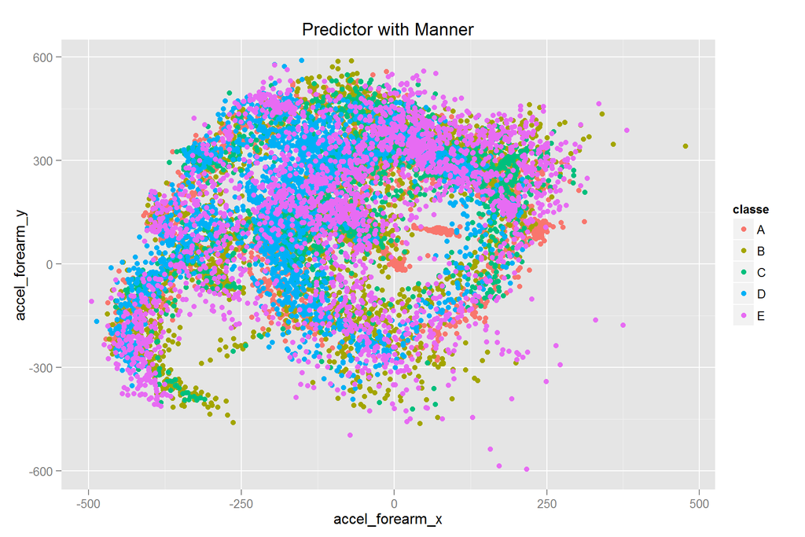

```r
qplot(accel_forearm_x ,accel_forearm_y,colour=classe,data=training,main="Predictor with Manner")
```

Looks none pattern there, in fact after trying alomost all variables from sensors, no obvious pattern observed which reminds us, that for this kind of complicated multiple variables’ predict Machine Learning techniques works better than human being’s intuition.

Since the HAR got an averaged accuracy rate of 78.8% (0.78+0.74+0.77+0.86+0.79)/5, see [here](http://groupware.les.inf.puc-rio.br/har), so before carrying out this predicting with Random Forest, the author expected the result of accuracy rate maybe at about 80 through 90 percent, or a little better.

```r
set.seed(137) # set seed for reproducible research purpose, but infact it doesn't work with this prediction for some random calculation occur.
fitControl <- trainControl(method = "none")
tgrid <- expand.grid(mtry=c(6))
modFit <- train(classe~ .,data=trainingLast,method="rf",prox=TRUE,trControl = fitControl, tuneGrid=tgrid) #method="rf" represents "Random forest" used.

#Show the predict accuracy distribution and error rate:
print(modFit$finalModel)
```

```
##
## Call:
##  randomForest(x = x, y = y, mtry = param$mtry, proximity = TRUE)
##                Type of random forest: classification
##                      Number of trees: 500
## No. of variables tried at each split: 6
##
##         OOB estimate of  error rate: 0.33%
## Confusion matrix:
##      A    B    C    D    E  class.error
## A 3905    0    0    0    1 0.0002560164
## B    6 2650    2    0    0 0.0030097818
## C    0   14 2382    0    0 0.0058430718
## D    0    0   18 2233    1 0.0084369449
## E    0    0    0    4 2521 0.0015841584
```

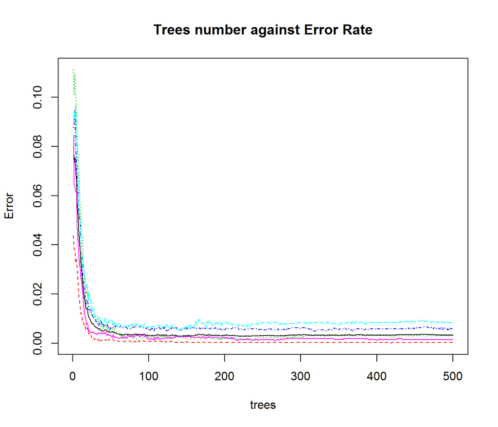

```r
#Plot to show the relationship between decision trees number with Error rate.
plot(modFit$finalModel,pch=19,cex=0.5,main="Trees number against Error Rate")
```

Readers could see that the error rate is very slow at 0.33% and only 46 wrong manner predicted in a 13737- row training set.

### Cross validation

The predicted model gotten from step above will be used directly for the testing dataset to carry out cross validation, or to say test how the model performs. With a high accuracy from trainning dataset, the author expected that the accuracy rate still be at a high rate over 99%, that’s because the sclicing method randomly to choose observations.

```r
pred <- predict(modFit,testingLast)# use the model modFit to predict against testing data.
testingLast$predRight <- pred==testingLast$classe # Add a new column for correct predicted cases
table(pred,testingLast$classe) # display the correct table
```

```
##
## pred    A    B    C    D    E
##    A 1674    0    0    0    0
##    B    0 1139    1    0    0
##    C    0    0 1025    1    0
##    D    0    0    0  963    0
##    E    0    0    0    0 1082
```

Here, the author do more with another slicing/cross validation technique named K-fold with trainingLast data set.

```r
folds <- createFolds(y=trainingLast$classe,k=10, list=TRUE,returnTrain=TRUE) #get returned dataset for sub-training, K=10 means slicing trainingLast into 10 sub-groups and will take each of these groups as testing set one by one.
#Here, only the group1 will be demonstrated.
modFitK10_1 <- train(classe~ .,data=trainingLast[folds[[1]],],method="rf",prox=TRUE,trControl = fitControl, tuneGrid=tgrid) #predict on the first group(9/10 observations)

#Show the predict accuracy distribution and error rate:
print(modFitK10_1$finalModel)
```

```
##
## Call:
##  randomForest(x = x, y = y, mtry = param$mtry, proximity = TRUE)
##                Type of random forest: classification
##                      Number of trees: 500
## No. of variables tried at each split: 6
##
##         OOB estimate of  error rate: 0.37%
## Confusion matrix:
##      A    B    C    D    E class.error
## A 3515    0    0    0    0 0.000000000
## B    6 2383    4    0    0 0.004178855
## C    0    9 2146    1    0 0.004638219
## D    0    0   19 2005    2 0.010365252
## E    0    0    0    5 2268 0.002199736
```

```r
testK10_1<-trainingLast[-folds[[1]],]#remnant observations in the orginal training dataset(trainingLast) to be testing data.
dim(testK10_1)# display the testing dataset observations from k-folded steps.
```

```
## [1] 1374   55
```

```r
predK10_1 <- predict(modFitK10_1,testK10_1)
# use the model modFit to predict against the
testK10_1$predRight <- predK10_1==testK10_1$classe # Add a new column for correct predicted cases
table(predK10_1,testK10_1$classe) # display the correct table
```

```
##
## predK10_1   A   B   C   D   E
##         A 391   0   0   0   0
##         B   0 265   1   0   0
##         C   0   0 239   0   0
##         D   0   0   0 226   2
##         E   0   0   0   0 250
```

[figure not shown]

```r
qplot(accel_forearm_x ,accel_forearm_y,colour=predRight,data=testingLast,main="newdata Predictions")
```

### Predicting against 20 real test data cases

This is actually just like the cross validation part but with a new testing dataset. Anyway, the code is listed without prediction result.

```r
TestFile20<-read.table("pml-testing.csv",header=TRUE,sep=",",na.strings="NA")
pred20 <- predict(modFit,newdata=TestFile20)
TestFile20$classe <- pred20 # Add the results as a new column which culd be compared with real values.
```

### Conclusion

Random Forest is really a good Machine Learning technique with high accuracy rate, which impressed the author so much. Readers could find more detailed knowledge about it [here](http://www.stat.berkeley.edu/~breiman/RandomForests/cc_home.htm) from website of University of California,Berkley, Deportment of Statistic.